# Bicycle accidents in Gdańsk from 2018 to 2022

Joanna Kaszubowska

# Introduction

The aim of this analysis is to investigate the factors influencing the number of bicycle accidents in Gdańsk from 2018 to 2022. For the study, data were collected from publicly available websites. Information on the number of accidents was obtained from sewik.pl. Data on bicycle rides were sourced from traffic intensity information provided by the City Office, and weather data were retrieved from danepubliczne.imgw.pl.

```r
summary(dane)
```

```
##  without.pedestrians2 with pedestrians      car           bicycle       motorcycle
##  Min.   : 1.00        Min.   :0.000    Min.   : 1.00   Min.   : 0.0   Min.   :0.0000
##  1st Qu.: 8.75        1st Qu.:0.000    1st Qu.: 8.00   1st Qu.: 1.0   1st Qu.:0.0000
##  Median :23.50        Median :1.000    Median :18.50   Median : 5.0   Median :0.0000
##  Mean   :22.50        Mean   :1.417    Mean   :18.15   Mean   : 6.7   Mean   :0.2167
##  3rd Qu.:32.50        3rd Qu.:2.000    3rd Qu.:26.25   3rd Qu.:12.0   3rd Qu.:0.0000
##  Max.   :52.00        Max.   :6.000    Max.   :45.00   Max.   :23.0   Max.   :2.0000
##  public transport     truck        pedestrian.crossing      road          roadway
##  Min.   :0.0000   Min.   :0.0000   Min.   :0.000       Min.   : 0.00   Min.   : 0.000
##  1st Qu.:0.0000   1st Qu.:0.0000   1st Qu.:0.000       1st Qu.: 1.00   1st Qu.: 3.000
##  Median :0.0000   Median :0.0000   Median :1.000       Median : 4.00   Median : 6.000
##  Mean   :0.3167   Mean   :0.7333   Mean   :1.117       Mean   : 4.65   Mean   : 7.367
##  3rd Qu.:0.0000   3rd Qu.:1.0000   3rd Qu.:2.000       3rd Qu.: 7.00   3rd Qu.:12.000
##  Max.   :3.0000   Max.   :4.0000   Max.   :6.000       Max.   :16.00   Max.   :19.000
##  cycle.crossing      pavement          temp        number.of.cyclists
##  Min.   : 0.000   Min.   :0.000   Min.   :-4.080   Min.   : 109917
##  1st Qu.: 3.000   1st Qu.:0.000   1st Qu.: 3.022   1st Qu.: 295356
##  Median : 7.000   Median :1.000   Median : 9.420   Median : 755680
##  Mean   : 6.883   Mean   :1.517   Mean   : 8.838   Mean   : 758882
##  3rd Qu.:11.000   3rd Qu.:2.000   3rd Qu.:15.175   3rd Qu.:1191768
##  Max.   :18.000   Max.   :8.000   Max.   :20.110   Max.   :1529660
```

# 1. PCA analysis

Due to different measurement scales, it was decided to standardize the variable values. Then, the correlation matrices of all variables were determined.

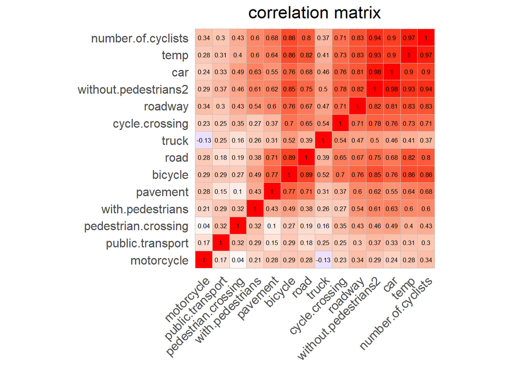

```r
dane_scale <- scale(dane)
dane_scale_frame <- data.frame(dane_scale)

cor_dane_scale_frame <- cor(dane_scale_frame, method='pearson')
ggcorrplot(cor_dane_scale_frame,
           lab = TRUE,
           method = "square",
           hc.order = TRUE,
           type = "full",
           colors = c("blue", "white", "red"),
           show.legend = FALSE,
           lab_size =2.2) +
  ggtitle("correlation matrix") +
  theme(plot.title = element_text(hjust = 0.5, size =17))
```

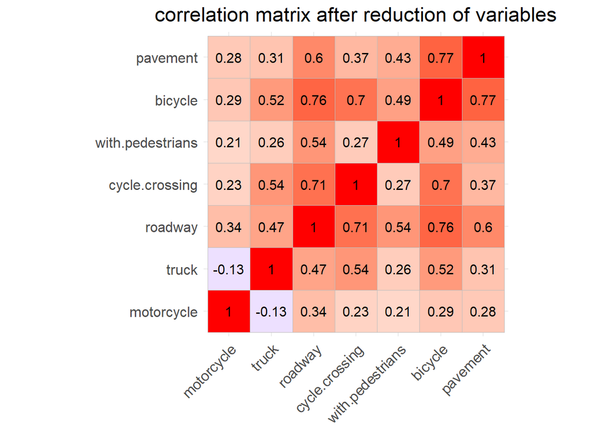

```r
dane_scale_frame2 <- dane_scale_frame[,c(2,4:5,7,10:12)]
cor_dane_scale_frame2 <- cor(dane_scale_frame2, method='pearson')
ggcorrplot(cor_dane_scale_frame2,
           lab = TRUE,
           method = "square",
           hc.order = TRUE,
           type = "full",
           colors = c("blue", "white", "red"),
           show.legend = FALSE) +
  ggtitle("correlation matrix after reduction of variables") +
  theme(plot.title = element_text(hjust = 0.5, size =17))
```

## 1.1. Selection of the main components

```r
wyniki <- princomp(dane_scale_frame2, cor=TRUE)
summary(wyniki)
```

```
## Importance of components:
##                           Comp.1    Comp.2    Comp.3     Comp.4     Comp.5     Comp.6     Comp.7
## Standard deviation     1.9368506 1.0783954 0.8804752 0.76600809 0.61813123 0.46747109 0.35078876
## Proportion of Variance 0.5359129 0.1661338 0.1107481 0.08382406 0.05458375 0.03121846 0.01757897
## Cumulative Proportion  0.5359129 0.7020467 0.8127948 0.89661883 0.95120258 0.98242103 1.00000000
```

```r
wyniki$sdev^2
```

```
##    Comp.1    Comp.2    Comp.3    Comp.4    Comp.5    Comp.6    Comp.7
## 3.7513902 1.1629367 0.7752365 0.5867684 0.3820862 0.2185292 0.1230528
```

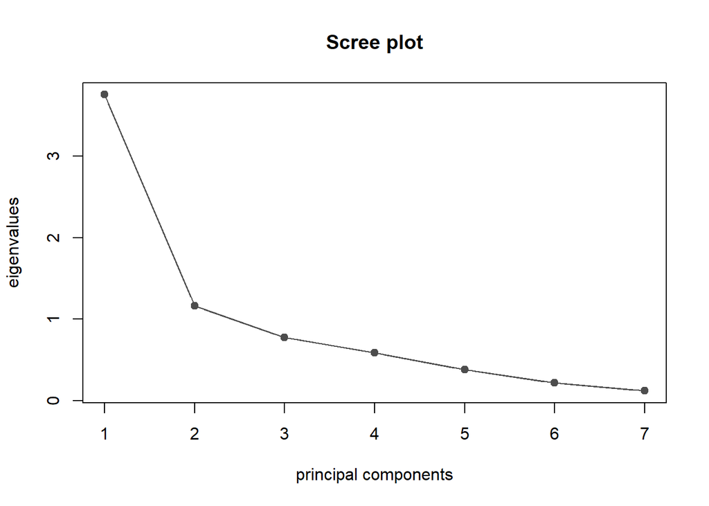

```r
plot(wyniki$sdev^2,
     type = "b",
     main = "Scree plot",
     xlab = "principal components",
     ylab = "eigenvalues",
     col = "grey30",
     pch = 19)
lines(wyniki$sdev^2, col = "grey30")
```

The results of the analysis show that the first 2 principal components explain nearly 70% of the cumulative variance. The first two components show eigenvalues above 1. The first principal component explains the largest part of the total variance. The graph shows a rapid decrease in eigenvalues in the initial components. After the 2nd component, the graph line begins to gradually flatten out. Based on the variability criterion, Kaiser’s criterion and Catelle’s rule, it can be concluded that the first 2 components should be taken into account for further analysis.

## 1.2. Loadings of variables of the first two principal components

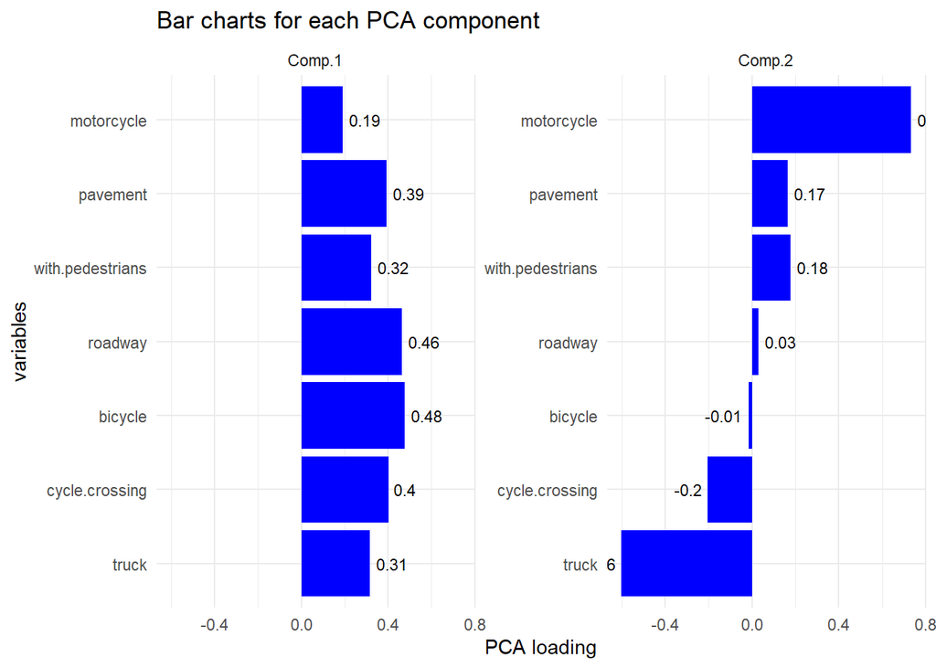

```r
loadings <- wyniki$loadings
top_2_loadings <- loadings[, 1:2]
top_2_loadings_df <- as.data.frame(top_2_loadings)
top_2_loadings_df$Variable <- rownames(top_2_loadings_df)

top_2_long <- pivot_longer(top_2_loadings_df,
                            cols = starts_with("Comp"),
                            names_to = "Principal_Component",
                            values_to = "Loading")

ggplot(top_2_long, aes(x = reorder(Variable, Loading), y = Loading)) +
  geom_bar(stat = "identity", fill = "blue") +
  geom_text(aes(label = round(Loading, 2)),
            hjust = ifelse(top_2_long$Loading < 0, 1.2, -0.2),
            color = "black", size = 3) +
  coord_flip() +
  facet_wrap(~ Principal_Component, scales = "free_y") +
  labs(x = "variables", y = "PCA loading",
       title = "Bar charts for each PCA component") +
  theme_minimal() +
  theme(legend.position = "none")
```

## 1.3. Correlation coefficients between original variables and principal components

```r
wyniki$loadings %*% diag(wyniki$sdev)[,1:2]
```

```
##                       [,1]        [,2]
## with.pedestrians 0.6233855  0.19177478
## bicycle          0.9249190 -0.01464438
## motorcycle       0.3713212  0.79086539
## truck            0.6091981 -0.64757596
## roadway          0.8963510  0.03312166
## cycle.crossing   0.7822499 -0.21915169
## pavement         0.7635076  0.17887832
```

## 1.4. biplot

[figure not shown]

```r
fviz_pca_biplot(wyniki, repel = TRUE) +
  ggtitle("Biplot of Principal Component Analysis") +
  theme(plot.title = element_text(hjust = 0.5, size =17)) +
  xlab("PCA2") +
  ylab("PCA1")
```

# 2. Model Poissona

### 2.1 Manual model design and optimization

At the beginning, it was decided to examine to what extent the main components obtained in the principal component analysis influence the explanation of the dependent variable, which is the number of accidents. For this purpose, two models were built: model 1, in which only the first principal component (PC1) was considered as an explanatory variable, model 2, in which both the first and the second principal components (PC1 and PC2) are explanatory variables.

```r
pca_scores <- data.frame(wyniki$scores[, 1:2])
colnames(pca_scores) <- c("PC1", "PC2")
dane_po_PCA <- cbind(daneee, pca_scores)

model1 <- glm(all.accidents ~ PC1,
                      family = poisson(link = "log"),
                      data = dane_po_PCA)
summary(model1)
```

```
##
## Call:
## glm(formula = all.accidents ~ PC1, family = poisson(link = "log"),
##     data = dane_po_PCA)
##
## Coefficients:
##             Estimate Std. Error z value Pr(>|z|)
## (Intercept)  3.02072    0.03020  100.03   <2e-16 ***
## PC1          0.27942    0.01316   21.23   <2e-16 ***
## ---
## Signif. codes:  0 '***' 0.001 '**' 0.01 '*' 0.05 '.' 0.1 ' ' 1
##
## (Dispersion parameter for poisson family taken to be 1)
##
##     Null deviance: 639.29  on 59  degrees of freedom
## Residual deviance: 187.55  on 58  degrees of freedom
## AIC: 474.53
##
## Number of Fisher Scoring iterations: 4
```

```r
model2 <- glm(all.accidents ~ PC1 + PC2,
          family = poisson(link = "log"),
          data = dane_po_PCA)
summary(model2)
```

```
##
## Call:
## glm(formula = all.accidents ~ PC1 + PC2, family = poisson(link = "log"),
##     data = dane_po_PCA)
##
## Coefficients:
##             Estimate Std. Error z value Pr(>|z|)
## (Intercept) 3.020499   0.030210  99.983   <2e-16 ***
## PC1         0.279674   0.013188  21.207   <2e-16 ***
## PC2         0.008029   0.019311   0.416    0.678
## ---
## Signif. codes:  0 '***' 0.001 '**' 0.01 '*' 0.05 '.' 0.1 ' ' 1
##
## (Dispersion parameter for poisson family taken to be 1)
##
##     Null deviance: 639.29  on 59  degrees of freedom
## Residual deviance: 187.38  on 57  degrees of freedom
## AIC: 476.36
##
## Number of Fisher Scoring iterations: 4
```

```r
anova(model1,model2, test = "Chisq")
```

|  | Resid. Df | Resid. Dev | Df | Deviance | Pr(>Chi) |
| --- | --- | --- | --- | --- | --- |
| 1 | 58 | 187.5478 | NA | NA | NA |
| 2 | 57 | 187.3755 | 1 | 0.1723433 | 0.6780376 |

Adding the PC2 component does not improve the model - the AIC value increased slightly, and the PC2 variable itself is not statistically significant. The results of the analysis of deviance (ANOVA) between the two Poisson models indicate that adding the second principal component (PC2) to the model does not lead to a significant improvement in the model’s fit to the data. The value of (Pr(>Chi)) is 0.68, so there is not enough evidence that adding PC2 to the model improves the model’s fit in a statistically significant way.

In the next step, it was decided to examine a model that would include as explanatory variables the original variables from the database that had some of the highest loadings in the first principal component (PC1). By trial and error, a model was sought that showed the lowest level of AIC and residual deviance. The best-fitting model, as explanatory variables, included the number of rides and the number of accidents at the bicycle crossing.

```r
model3 <- glm(all.accidents ~  number.of.cyclists + cycle.crossing,
                       family = poisson(link="log"),
                       data = dane_po_PCA)
summary(model3)
```

```
##
## Call:
## glm(formula = all.accidents ~ number.of.cyclists + cycle.crossing,
##     family = poisson(link = "log"), data = dane_po_PCA)
##
## Coefficients:
##                     Estimate Std. Error z value Pr(>|z|)
## (Intercept)        1.902e+00  7.215e-02  26.363  < 2e-16 ***
## number.of.cyclists 1.152e-06  7.788e-08  14.795  < 2e-16 ***
## cycle.crossing     2.917e-02  6.974e-03   4.182 2.89e-05 ***
## ---
## Signif. codes:  0 '***' 0.001 '**' 0.01 '*' 0.05 '.' 0.1 ' ' 1
##
## (Dispersion parameter for poisson family taken to be 1)
##
##     Null deviance: 639.29  on 59  degrees of freedom
## Residual deviance: 111.17  on 57  degrees of freedom
## AIC: 400.16
##
## Number of Fisher Scoring iterations: 4
```

```r
anova(model1,model3, test = "Chisq")
```

|  | Resid. Df | Resid. Dev | Df | Deviance | Pr(>Chi) |
| --- | --- | --- | --- | --- | --- |
| 1 | 58 | 187.5478 | NA | NA | NA |
| 2 | 57 | 111.1722 | 1 | 76.37555 | 2.345374e-18 |

```r
ocena_modelu_GLM <- function(model) {
  st_dev_of_res <- (model$deviance/model$df.residual)^0.5
  AIC <- model$aic
  invisible (capture.output({
  McFadden<- pR2(model)[4]
  Cragg_Uhler<- pR2(model)[6]}))
  ocena <- data.frame(st_dev_of_res, AIC, McFadden, Cragg_Uhler)
  return(ocena)
}
ocena_modeli <- rbind(
  model1 =ocena_modelu_GLM(model1),
  model2 = ocena_modelu_GLM(model2),
  model3 = ocena_modelu_GLM(model3))

ocena_modeli
```

|  | st_dev_of_res | AIC | McFadden | Cragg_Uhler |
| --- | --- | --- | --- | --- |
| model1 | 1.798217 | 474.5308 | 0.4898159 | 0.9994630 |
| model2 | 1.813088 | 476.3584 | 0.4900027 | 0.9994645 |
| model3 | 1.396564 | 400.1552 | 0.5726279 | 0.9998498 |

A model with two original variables was selected for further analyses, because they show a better fit to the data and more stable results (lower standard deviation of residuals - smaller prediction error, lower AIC value - better model fit, lower value of residual deviance - better explanation of data variability, higher pseudo R2 value in the McFadden and Cragg_Uhler tests - better explanation of data variability). The ANOVA test result indicates that the improvement compared to Model 1 is statistically significant. PCA analysis was helpful in selecting significant predictors.

### 2.2 Test of significance of all independent variables in the model

```r
waldtest(model3)
```

|  | Res.Df | Df | F | Pr(>F) |
| --- | --- | --- | --- | --- |
| 1 | 57 | NA | NA | NA |
| 2 | 59 | -2 | 236.0318 | 2.645214e-28 |

The result of the Wald test is highly statistically significant, so we reject the null hypothesis of no influence of the explanatory variables on the number of bicycle accidents. A high value of the F statistic indicates high statistical significance of the test.

## 2.3. Diagnostic charts

### Residual plot

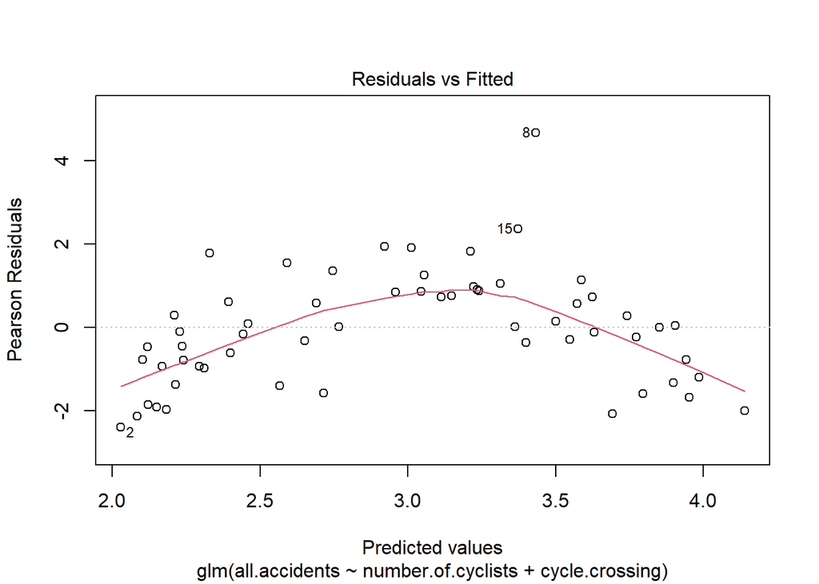

```r
plot(model3, which = 1)
```

The residual plot for Model 3 shows a certain curvilinear pattern, which may mean that the relationship between predictors and the number of accidents is not linear. It was decided to additionally check the presence and influence of influential and outlier observations.

### Identification of influential and outlier observations

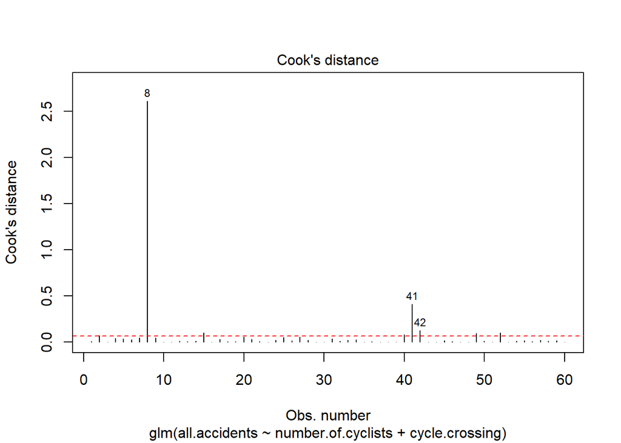

```r
plot(model3, which = 4)
cooks_values <- cooks.distance(model3)
abline(h = 4 / nrow(dane_po_PCA), col = "red", lty = 2)
```

```r
outlierTest(model3)
```

```
##   rstudent unadjusted p-value Bonferroni p
## 8 4.858386         1.1835e-06   7.1008e-05
```

```r
model4 <- glm(all.accidents ~  number.of.cyclists + cycle.crossing,
                       family = poisson(link="log"),
                       data = dane_po_PCA, subset = c(1:7,9:40, 43:60))
summary(model4)
```

```
##
## Call:
## glm(formula = all.accidents ~ number.of.cyclists + cycle.crossing,
##     family = poisson(link = "log"), data = dane_po_PCA, subset = c(1:7,
##         9:40, 43:60))
##
## Coefficients:
##                     Estimate Std. Error z value Pr(>|z|)
## (Intercept)        1.825e+00  7.588e-02  24.044  < 2e-16 ***
## number.of.cyclists 1.007e-06  8.894e-08  11.327  < 2e-16 ***
## cycle.crossing     5.325e-02  8.516e-03   6.252 4.04e-10 ***
## ---
## Signif. codes:  0 '***' 0.001 '**' 0.01 '*' 0.05 '.' 0.1 ' ' 1
##
## (Dispersion parameter for poisson family taken to be 1)
##
##     Null deviance: 582.089  on 56  degrees of freedom
## Residual deviance:  78.632  on 54  degrees of freedom
## AIC: 350.67
##
## Number of Fisher Scoring iterations: 4
```

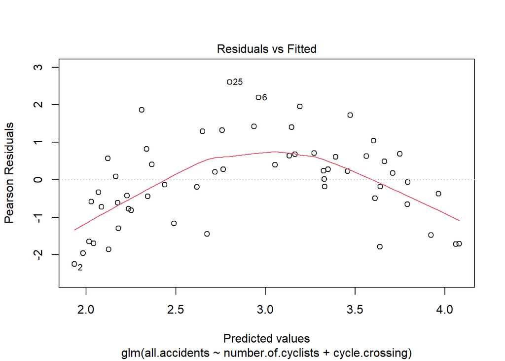

```r
plot(model4, which = 1)
```

After removing outliers and influential values, a significant improvement in model fit was observed. However, the residual plot still shows a curvilinear pattern. Therefore, the decision was made to apply log transformation to the explanatory variables to better capture this nonlinearity and improve the model fit.

```r
dane_po_PCA$log_number.of.cyclists <- log(dane_po_PCA$number.of.cyclists + 1)
dane_po_PCA$log_cycle.crossing <- log(dane_po_PCA$cycle.crossing + 1)

model5 <- glm(all.accidents ~ log_number.of.cyclists + log_cycle.crossing,
                 family = poisson(link = "log"), data = dane_po_PCA, subset = c(1:7,9:40, 43:60))
summary(model5)
```

```
##
## Call:
## glm(formula = all.accidents ~ log_number.of.cyclists + log_cycle.crossing,
##     family = poisson(link = "log"), data = dane_po_PCA, subset = c(1:7,
##         9:40, 43:60))
##
## Coefficients:
##                        Estimate Std. Error z value Pr(>|z|)
## (Intercept)            -7.34181    0.92370  -7.948 1.89e-15 ***
## log_number.of.cyclists  0.71834    0.07654   9.385  < 2e-16 ***
## log_cycle.crossing      0.37683    0.07960   4.734 2.20e-06 ***
## ---
## Signif. codes:  0 '***' 0.001 '**' 0.01 '*' 0.05 '.' 0.1 ' ' 1
##
## (Dispersion parameter for poisson family taken to be 1)
##
##     Null deviance: 582.09  on 56  degrees of freedom
## Residual deviance:  40.33  on 54  degrees of freedom
## AIC: 312.37
##
## Number of Fisher Scoring iterations: 4
```

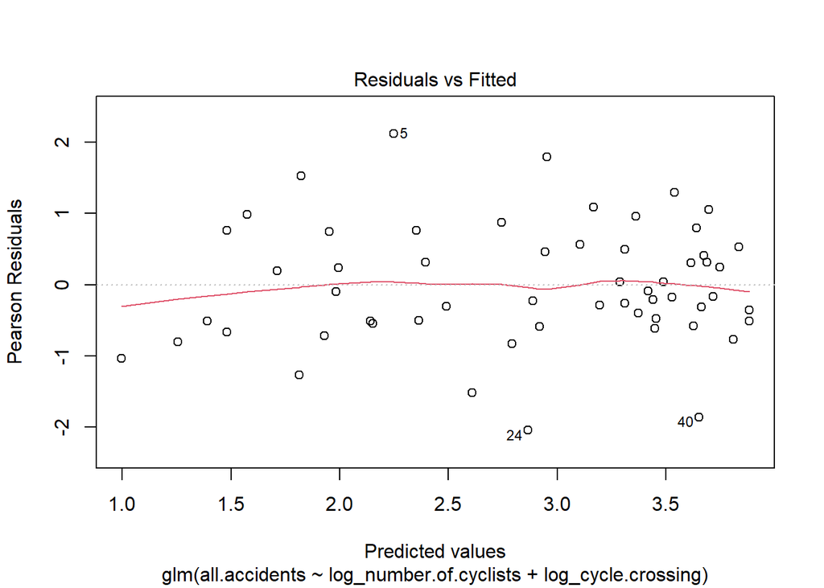

```r
plot(model5, which = 1)
```

After applying a log transformation of the explanatory variables, the residual plot shows an improvement in model fit compared to previous versions.

```r
model_evaluation_GLM <- function(model) {
  st_dev_of_res <- (model$deviance/model$df.residual)^0.5
  AIC <- model$aic
  invisible (capture.output({
  McFadden<- pR2(model)[4]
  Cragg_Uhler<- pR2(model)[6]}))
  ocena <- data.frame(st_dev_of_res, AIC, McFadden, Cragg_Uhler)
  return(ocena)
}
model_evaluation <- rbind(
  model4 = model_evaluation_GLM(model4),
  model5 = model_evaluation_GLM(model5))

model_evaluation
```

|  | st_dev_of_res | AIC | McFadden | Cragg_Uhler |
| --- | --- | --- | --- | --- |
| model4 | 1.2067076 | 350.6702 | 0.5575742 | 0.9995109 |
| model5 | 0.8642092 | 312.3687 | 0.6067388 | 0.9997508 |

# Conclusions

The Poisson model with log transformation of variables gives a relatively good fit, with significant variables affecting the number of accidents, although there is scope for further optimization, especially in the nonlinear relationships.

The estimate for the first variable is 0.71834, which means that if the log of the number of trips (log_number.of.cyclists) increases by 1 unit, the expected number of accidents increases by exp(0.71834). This is a significant variable indicating a higher risk of accidents as traffic density increases.

The estimate for the second variable is 0.37683, which means that if the log of the number of accidents at bicycle crossings (log_cycle.crossing) increases by 1 unit, the expected number of accidents increases by exp(0.37683)

More road traffic, as measured by the number of trips, is associated with a higher risk of accidents, which is consistent with the intuition that higher traffic density increases the risk of collisions.

The increase in the number of accidents at bicycle crossings is associated with the overall increase in the number of road accidents, which suggests the need to improve the infrastructure and safety of these crossings.

Nonlinear Relationships and Model Refinement Some relationships may not be fully captured in a linear model, suggesting the potential benefit of incorporating interaction terms or nonlinear transformations for better predictive power.

Infrastructure and Urban Planning Implications The results highlight the need for better urban planning, including the redesign of high-risk intersections, improved lighting, and dedicated bike lanes to reduce accident frequency.

Potential for Predictive Use The Poisson model can serve as a predictive tool to estimate accident frequency based on traffic and environmental factors, aiding decision-makers in risk assessment and mitigation strategies.

Further Research Directions Including additional variables such as driver behavior, road surface conditions, or more granular spatial data could improve the model’s accuracy and lead to more actionable insights.